# Sleep Disorder based on Lifestyle_Logistics regression and Random Forest

## About the Dataset

This Project is utilizing the Sleep Health and Lifestyle Dataset in Kaggle, A secondary Data. This is basically measuring the impart of someone's lifestyle on their health.

The Dataset contains 14 columns in total (That is, 13 features and 1 classification columns with 3 labels/category/mulitclass - None, Sleep Aspnea and Insomnia). The dataset contains 374 rows in total excluding the data header row

The 13 features includes; **Person Identifier (ID),** Gender (Male/Female), **Age (In years), Occupation(Profession of the Person),** Sleep duration (In hours per day), **Quality of Sleep (On a scale rating 1-10 with 1- no significance, 5-medium significance and 9/10-high significance...It is a subjectice rating based on feelings and opinions),** Physical Activity Level (In minutes per day, **Stress Level (On a scale rating of 1-10, measure how stress level experienced by the Individual, it is also subjective rating),** Systolic Blood Pressure in mmHg, **Diastolic Blood Pressure in mmHg,** Heart rate in bpm (Beat per minutes), **Daily Steps (In count),** The Classification Column is the SLEEP DISORDER COLUMN with 3 labels - None, Sleep Apnea and Insomnia

### The Aim of this Project

This study aimed at utilising logistics Regression and Randomforest to model the best predictors for determining what features affect the sleep health of some certain Professions based on their Lifestyle and classifying the Sleep Disorder class.

### Importing the Necessary Libraries for the Data Processing

```python
import numpy as np
import pandas as pd
import matplotlib.pyplot as plt
import seaborn as sns
%matplotlib inline
from sklearn.model_selection import train_test_split
from sklearn.metrics import accuracy_score, precision_score, recall_score, f1_score, confusion_matrix
```

```python
Sleep_Lifestyle_dt = pd.read_csv('Sleep_health_and_lifestyle_dataset.csv')
```

## Data Cleaning and Data Exploration

Data cleaning is the process of fixing or removing incorrect, corrupted, incorrectly formatted, duplicate, or incomplete data within a dataset

Data Exploration is a technique used to understand the various aspect of your dataset including the visualization and statistcial evaluation of the dataset to be able to summarize the characteristics and uniqueness of the dataset

```python
## This will read the first 5 rows in the dataset
Sleep_Lifestyle_dt.head()
```

|  | Person ID | Gender | Age | Occupation | Sleep Duration | Quality of Sleep | Physical Activity Level | Stress Level | BMI Category | Systolic Blood Pressure | Diastolic Blood Pressure | Heart Rate | Daily Steps | Sleep Disorder |
| --- | --- | --- | --- | --- | --- | --- | --- | --- | --- | --- | --- | --- | --- | --- |
| 0 | 1 | Male | 27 | Software Engineer | 6.1 | 6 | 42 | 6 | Overweight | 126 | 83 | 77 | 4200 | None |
| 1 | 2 | Male | 28 | Doctor | 6.2 | 6 | 60 | 8 | Normal | 125 | 80 | 75 | 10000 | None |
| 2 | 3 | Male | 28 | Doctor | 6.2 | 6 | 60 | 8 | Normal | 125 | 80 | 75 | 10000 | None |
| 3 | 4 | Male | 28 | Sales Representative | 5.9 | 4 | 30 | 8 | Obese | 140 | 90 | 85 | 3000 | Sleep Apnea |
| 4 | 5 | Male | 28 | Sales Representative | 5.9 | 4 | 30 | 8 | Obese | 140 | 90 | 85 | 3000 | Sleep Apnea |

```python
##This is reading out the last 5 rows in the dataset
Sleep_Lifestyle_dt.tail()
```

|  | Person ID | Gender | Age | Occupation | Sleep Duration | Quality of Sleep | Physical Activity Level | Stress Level | BMI Category | Systolic Blood Pressure | Diastolic Blood Pressure | Heart Rate | Daily Steps | Sleep Disorder |
| --- | --- | --- | --- | --- | --- | --- | --- | --- | --- | --- | --- | --- | --- | --- |
| 369 | 370 | Female | 59 | Nurse | 8.1 | 9 | 75 | 3 | Overweight | 140 | 95 | 68 | 7000 | Sleep Apnea |
| 370 | 371 | Female | 59 | Nurse | 8.0 | 9 | 75 | 3 | Overweight | 140 | 95 | 68 | 7000 | Sleep Apnea |
| 371 | 372 | Female | 59 | Nurse | 8.1 | 9 | 75 | 3 | Overweight | 140 | 95 | 68 | 7000 | Sleep Apnea |
| 372 | 373 | Female | 59 | Nurse | 8.1 | 9 | 75 | 3 | Overweight | 140 | 95 | 68 | 7000 | Sleep Apnea |
| 373 | 374 | Female | 59 | Nurse | 8.1 | 9 | 75 | 3 | Overweight | 140 | 95 | 68 | 7000 | Sleep Apnea |

```python
#The loc[0] is used to locate the row with the index [0] which is the first row in the dataset

print(Sleep_Lifestyle_dt.loc[0])
```

```
Person ID                                   1
Gender                                   Male
Age                                        27
Occupation                  Software Engineer
Sleep Duration                            6.1
Quality of Sleep                            6
Physical Activity Level                    42
Stress Level                                6
BMI Category                       Overweight
Systolic Blood Pressure                   126
Diastolic Blood Pressure                   83
Heart Rate                                 77
Daily Steps                              4200
Sleep Disorder                           None
Name: 0, dtype: object
```

```python
Sleep_Lifestyle_dt.info() #There is no missing value in the dataset
```

```
<class 'pandas.core.frame.DataFrame'>
RangeIndex: 374 entries, 0 to 373
Data columns (total 14 columns):
 #   Column                    Non-Null Count  Dtype
---  ------                    --------------  -----
 0   Person ID                 374 non-null    int64
 1   Gender                    374 non-null    object
 2   Age                       374 non-null    int64
 3   Occupation                374 non-null    object
 4   Sleep Duration            374 non-null    float64
 5   Quality of Sleep          374 non-null    int64
 6   Physical Activity Level   374 non-null    int64
 7   Stress Level              374 non-null    int64
 8   BMI Category              374 non-null    object
 9   Systolic Blood Pressure   374 non-null    int64
 10  Diastolic Blood Pressure  374 non-null    int64
 11  Heart Rate                374 non-null    int64
 12  Daily Steps               374 non-null    int64
 13  Sleep Disorder            374 non-null    object
dtypes: float64(1), int64(9), object(4)
memory usage: 41.0+ KB
```

```python
Sleep_Lifestyle_dt.isna().sum()
#This shows that there is no missing values in the dataset
```

```
Person ID                   0
Gender                      0
Age                         0
Occupation                  0
Sleep Duration              0
Quality of Sleep            0
Physical Activity Level     0
Stress Level                0
BMI Category                0
Systolic Blood Pressure     0
Diastolic Blood Pressure    0
Heart Rate                  0
Daily Steps                 0
Sleep Disorder              0
dtype: int64
```

```python
Sleep_Lifestyle_dt.duplicated().sum()
#This is used to check the number of duplicates in the dataset and it shows there is no duplicates in the dataset
```

```
0
```

```python
Sleep_Lifestyle_dt.count() #This shows the count of the dataset per column
```

```
Person ID                   374
Gender                      374
Age                         374
Occupation                  374
Sleep Duration              374
Quality of Sleep            374
Physical Activity Level     374
Stress Level                374
BMI Category                374
Systolic Blood Pressure     374
Diastolic Blood Pressure    374
Heart Rate                  374
Daily Steps                 374
Sleep Disorder              374
dtype: int64
```

```python
# This is used to drop the Person ID column because it is not valuable for use.
Sleep_Lifestyle_dt = Sleep_Lifestyle_dt.drop(['Person ID'], axis=1)
```

#### Different Plots to Visualize the Data

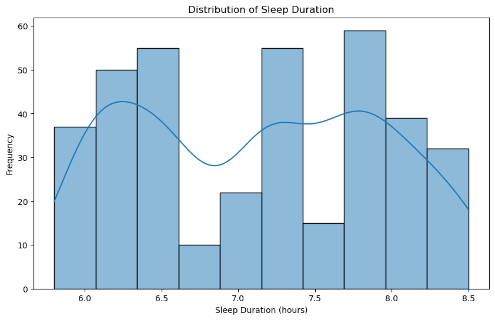

```python
### Distribution of Sleep Duration
plt.figure(figsize=(10, 6))
sns.histplot(Sleep_Lifestyle_dt['Sleep Duration'], bins=10, kde=True)
plt.title('Distribution of Sleep Duration')
plt.xlabel('Sleep Duration (hours)')
plt.ylabel('Frequency')
plt.show()
```

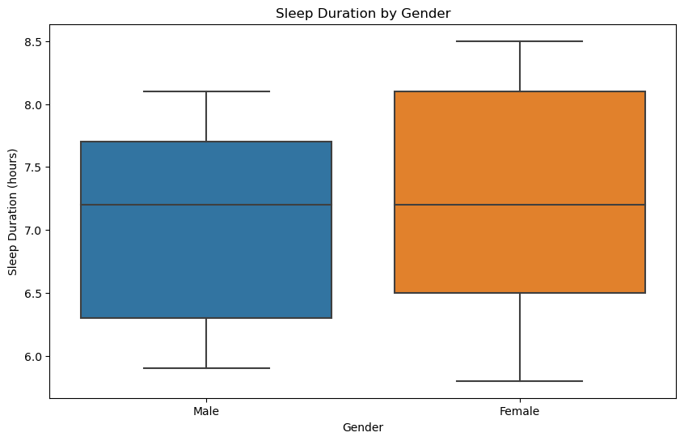

```python
### Sleep Duration by Gender
plt.figure(figsize=(10, 6))
sns.boxplot(x='Gender', y='Sleep Duration', data=Sleep_Lifestyle_dt)
plt.title('Sleep Duration by Gender')
plt.xlabel('Gender')
plt.ylabel('Sleep Duration (hours)')
plt.show()
```

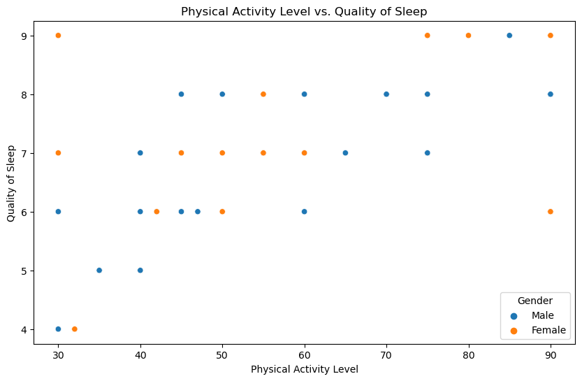

```python
### Physical Activity Level vs. Quality of Sleep

plt.figure(figsize=(10, 6))
sns.scatterplot(x='Physical Activity Level', y='Quality of Sleep', hue='Gender', data=Sleep_Lifestyle_dt)
plt.title('Physical Activity Level vs. Quality of Sleep')
plt.xlabel('Physical Activity Level')
plt.ylabel('Quality of Sleep')
plt.show()
```

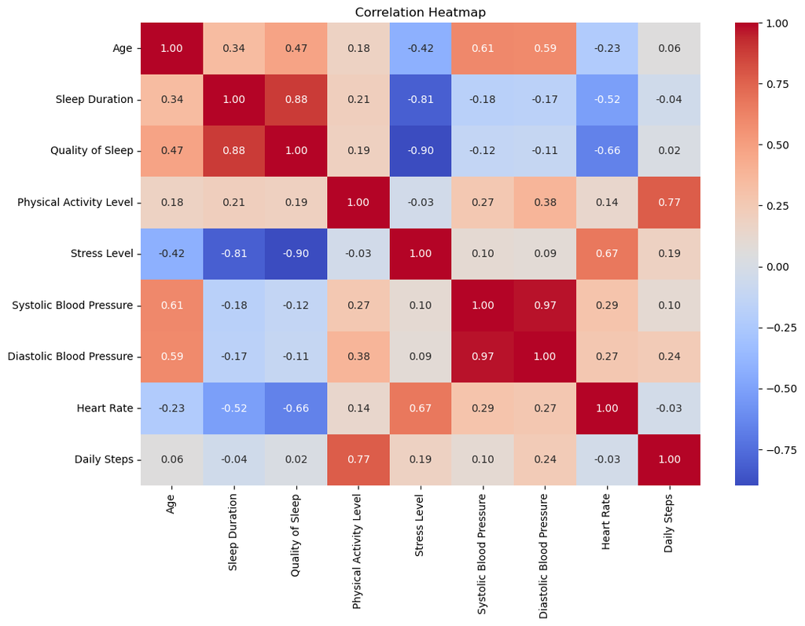

```python
### Correlation Heatmap was only done for the numerical values in the dataset...
plt.figure(figsize=(12, 8))
corr = Sleep_Lifestyle_dt.corr()
sns.heatmap(corr, annot=True, cmap='coolwarm', fmt='.2f')
plt.title('Correlation Heatmap')
plt.show()
```

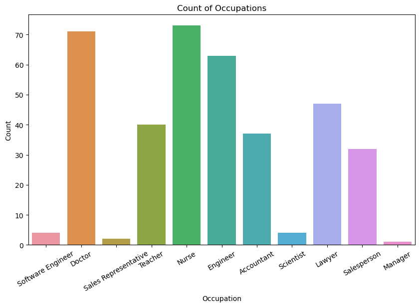

```python
### Count Plot of Occupation
plt.figure(figsize=(10, 6))
sns.countplot(x='Occupation', data=Sleep_Lifestyle_dt)
plt.title('Count of Occupations')
plt.xlabel('Occupation')
plt.ylabel('Count')
plt.xticks(rotation=30)
plt.show()
```

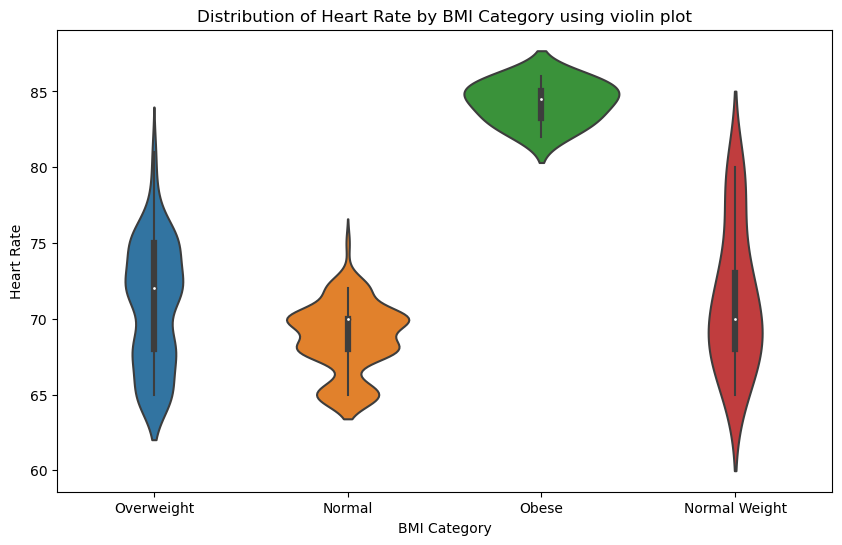

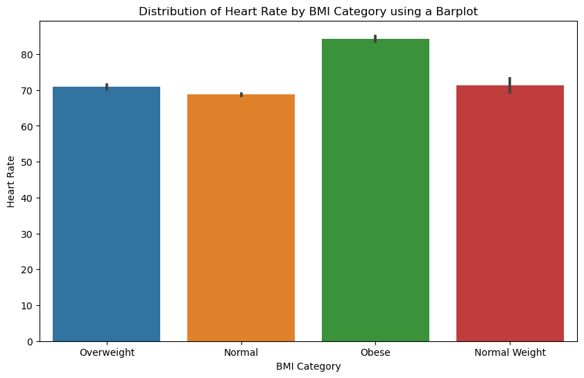

```python
## Distribution of Heart Rate by BMI Category using violinplot
plt.figure(figsize=(10, 6))
sns.violinplot(x='BMI Category', y='Heart Rate', data=Sleep_Lifestyle_dt)
plt.title('Distribution of Heart Rate by BMI Category using violin plot')
plt.xlabel('BMI Category')
plt.ylabel('Heart Rate')
plt.show()



## Distribution of Heart Rate by BMI Category using the barplot
plt.figure(figsize=(10, 6))
sns.barplot(x='BMI Category', y='Heart Rate', data=Sleep_Lifestyle_dt)
plt.title('Distribution of Heart Rate by BMI Category using a Barplot')
plt.xlabel('BMI Category')
plt.ylabel('Heart Rate')
plt.show()
```

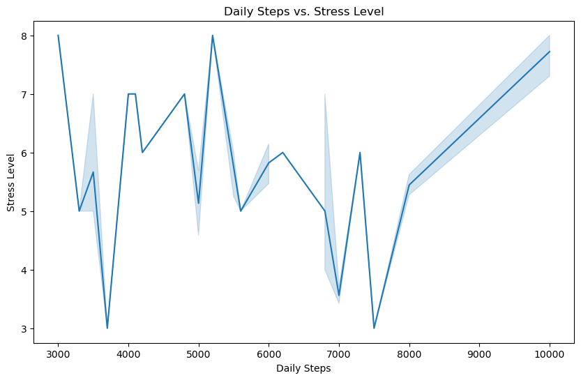

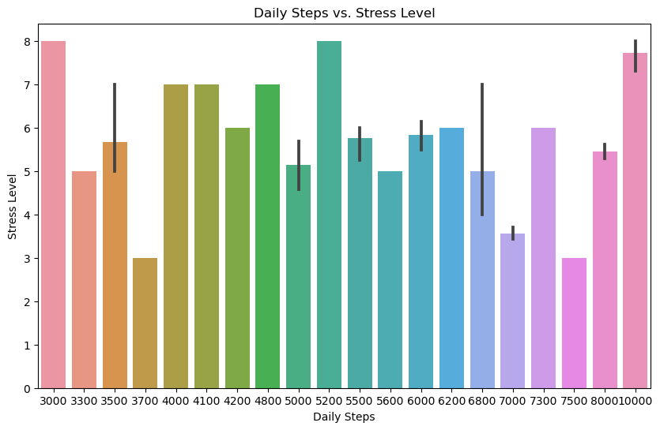

```python
### Daily Steps vs. Stress Level
plt.figure(figsize=(10, 6))
sns.lineplot(x='Daily Steps', y='Stress Level', data=Sleep_Lifestyle_dt)
plt.title('Daily Steps vs. Stress Level')
plt.xlabel('Daily Steps')
plt.ylabel('Stress Level')
plt.show()



plt.figure(figsize=(10, 6))
sns.barplot(x='Daily Steps', y='Stress Level', data=Sleep_Lifestyle_dt)
plt.title('Daily Steps vs. Stress Level')
plt.xlabel('Daily Steps')
plt.ylabel('Stress Level')
plt.show()
```

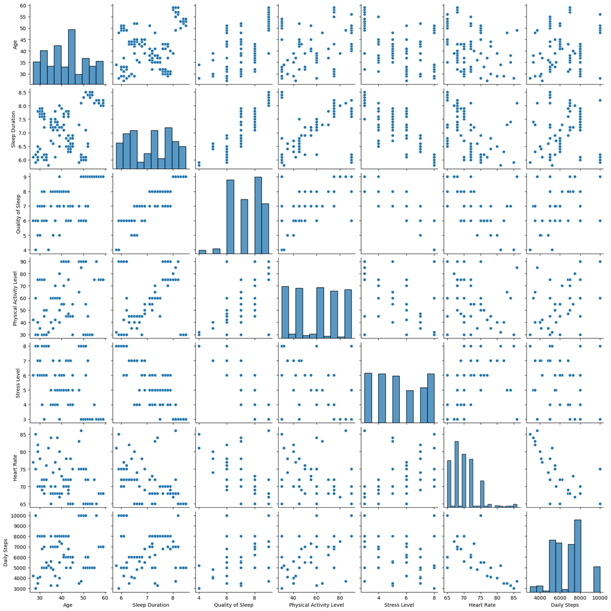

```python
### Pair Plot for Numerical Features
plt.figure(figsize=(12, 12))
sns.pairplot(Sleep_Lifestyle_dt[['Age', 'Sleep Duration', 'Quality of Sleep', 'Physical Activity Level', 'Stress Level', 'Heart Rate', 'Daily Steps']])
plt.show()
```

### Convert the categorical features to numerical and also perform some statistical Analysis

```python
## Copying/Saving the dataset into another dataframe
Sleep_Lifestyle_dt_2 = Sleep_Lifestyle_dt.copy()
Sleep_Lifestyle_dt_2.head()
```

|  | Gender | Age | Occupation | Sleep Duration | Quality of Sleep | Physical Activity Level | Stress Level | BMI Category | Systolic Blood Pressure | Diastolic Blood Pressure | Heart Rate | Daily Steps | Sleep Disorder |
| --- | --- | --- | --- | --- | --- | --- | --- | --- | --- | --- | --- | --- | --- |
| 0 | Male | 27 | Software Engineer | 6.1 | 6 | 42 | 6 | Overweight | 126 | 83 | 77 | 4200 | None |
| 1 | Male | 28 | Doctor | 6.2 | 6 | 60 | 8 | Normal | 125 | 80 | 75 | 10000 | None |
| 2 | Male | 28 | Doctor | 6.2 | 6 | 60 | 8 | Normal | 125 | 80 | 75 | 10000 | None |
| 3 | Male | 28 | Sales Representative | 5.9 | 4 | 30 | 8 | Obese | 140 | 90 | 85 | 3000 | Sleep Apnea |
| 4 | Male | 28 | Sales Representative | 5.9 | 4 | 30 | 8 | Obese | 140 | 90 | 85 | 3000 | Sleep Apnea |

```python
#Using the LabelEncorder Class()
from sklearn.preprocessing import LabelEncoder

# Convert categorical data to numerical data using LabelEncoder
le = LabelEncoder()
Sleep_Lifestyle_dt_2['Gender'] = le.fit_transform(Sleep_Lifestyle_dt['Gender'])

# View the converted DataFrame
Sleep_Lifestyle_dt_2.head() #Male = 1 and Female = 0
```

|  | Gender | Age | Occupation | Sleep Duration | Quality of Sleep | Physical Activity Level | Stress Level | BMI Category | Systolic Blood Pressure | Diastolic Blood Pressure | Heart Rate | Daily Steps | Sleep Disorder |
| --- | --- | --- | --- | --- | --- | --- | --- | --- | --- | --- | --- | --- | --- |
| 0 | 1 | 27 | Software Engineer | 6.1 | 6 | 42 | 6 | Overweight | 126 | 83 | 77 | 4200 | None |
| 1 | 1 | 28 | Doctor | 6.2 | 6 | 60 | 8 | Normal | 125 | 80 | 75 | 10000 | None |
| 2 | 1 | 28 | Doctor | 6.2 | 6 | 60 | 8 | Normal | 125 | 80 | 75 | 10000 | None |
| 3 | 1 | 28 | Sales Representative | 5.9 | 4 | 30 | 8 | Obese | 140 | 90 | 85 | 3000 | Sleep Apnea |
| 4 | 1 | 28 | Sales Representative | 5.9 | 4 | 30 | 8 | Obese | 140 | 90 | 85 | 3000 | Sleep Apnea |

```python
# Convert categorical data to numerical data using replace() method
Sleep_Lifestyle_dt_2['BMI Category'] = Sleep_Lifestyle_dt_2['BMI Category'].replace({'Normal': 1, 'Normal Weight': 1, 'Overweight': 2, 'Obese':3})

# View the converted DataFrame
Sleep_Lifestyle_dt_2.head(20)
```

|  | Gender | Age | Occupation | Sleep Duration | Quality of Sleep | Physical Activity Level | Stress Level | BMI Category | Systolic Blood Pressure | Diastolic Blood Pressure | Heart Rate | Daily Steps | Sleep Disorder |
| --- | --- | --- | --- | --- | --- | --- | --- | --- | --- | --- | --- | --- | --- |
| 0 | 1 | 27 | Software Engineer | 6.1 | 6 | 42 | 6 | 2 | 126 | 83 | 77 | 4200 | None |
| 1 | 1 | 28 | Doctor | 6.2 | 6 | 60 | 8 | 1 | 125 | 80 | 75 | 10000 | None |
| 2 | 1 | 28 | Doctor | 6.2 | 6 | 60 | 8 | 1 | 125 | 80 | 75 | 10000 | None |
| 3 | 1 | 28 | Sales Representative | 5.9 | 4 | 30 | 8 | 3 | 140 | 90 | 85 | 3000 | Sleep Apnea |
| 4 | 1 | 28 | Sales Representative | 5.9 | 4 | 30 | 8 | 3 | 140 | 90 | 85 | 3000 | Sleep Apnea |
| 5 | 1 | 28 | Software Engineer | 5.9 | 4 | 30 | 8 | 3 | 140 | 90 | 85 | 3000 | Insomnia |
| 6 | 1 | 29 | Teacher | 6.3 | 6 | 40 | 7 | 3 | 140 | 90 | 82 | 3500 | Insomnia |
| 7 | 1 | 29 | Doctor | 7.8 | 7 | 75 | 6 | 1 | 120 | 80 | 70 | 8000 | None |
| 8 | 1 | 29 | Doctor | 7.8 | 7 | 75 | 6 | 1 | 120 | 80 | 70 | 8000 | None |
| 9 | 1 | 29 | Doctor | 7.8 | 7 | 75 | 6 | 1 | 120 | 80 | 70 | 8000 | None |
| 10 | 1 | 29 | Doctor | 6.1 | 6 | 30 | 8 | 1 | 120 | 80 | 70 | 8000 | None |
| 11 | 1 | 29 | Doctor | 7.8 | 7 | 75 | 6 | 1 | 120 | 80 | 70 | 8000 | None |
| 12 | 1 | 29 | Doctor | 6.1 | 6 | 30 | 8 | 1 | 120 | 80 | 70 | 8000 | None |
| 13 | 1 | 29 | Doctor | 6.0 | 6 | 30 | 8 | 1 | 120 | 80 | 70 | 8000 | None |
| 14 | 1 | 29 | Doctor | 6.0 | 6 | 30 | 8 | 1 | 120 | 80 | 70 | 8000 | None |
| 15 | 1 | 29 | Doctor | 6.0 | 6 | 30 | 8 | 1 | 120 | 80 | 70 | 8000 | None |
| 16 | 0 | 29 | Nurse | 6.5 | 5 | 40 | 7 | 1 | 132 | 87 | 80 | 4000 | Sleep Apnea |
| 17 | 1 | 29 | Doctor | 6.0 | 6 | 30 | 8 | 1 | 120 | 80 | 70 | 8000 | Sleep Apnea |
| 18 | 0 | 29 | Nurse | 6.5 | 5 | 40 | 7 | 1 | 132 | 87 | 80 | 4000 | Insomnia |
| 19 | 1 | 30 | Doctor | 7.6 | 7 | 75 | 6 | 1 | 120 | 80 | 70 | 8000 | None |

```python
# Convert categorical data to numerical data using replace
Sleep_Lifestyle_dt_2['Occupation'] = Sleep_Lifestyle_dt_2['Occupation'].replace({'Accountant': 1, 'Doctor': 2, 'Engineer': 3, 'Lawyer':4, 'Manager': 5, 'Nurse': 6, 'Sales Representative': 7, 'Salesperson': 8, 'Scientist': 9, 'Software Engineer': 10, 'Teacher': 11})

# View the converted DataFrame
Sleep_Lifestyle_dt_2.head(10)
```

|  | Gender | Age | Occupation | Sleep Duration | Quality of Sleep | Physical Activity Level | Stress Level | BMI Category | Systolic Blood Pressure | Diastolic Blood Pressure | Heart Rate | Daily Steps | Sleep Disorder |
| --- | --- | --- | --- | --- | --- | --- | --- | --- | --- | --- | --- | --- | --- |
| 0 | 1 | 27 | 10 | 6.1 | 6 | 42 | 6 | 2 | 126 | 83 | 77 | 4200 | None |
| 1 | 1 | 28 | 2 | 6.2 | 6 | 60 | 8 | 1 | 125 | 80 | 75 | 10000 | None |
| 2 | 1 | 28 | 2 | 6.2 | 6 | 60 | 8 | 1 | 125 | 80 | 75 | 10000 | None |
| 3 | 1 | 28 | 7 | 5.9 | 4 | 30 | 8 | 3 | 140 | 90 | 85 | 3000 | Sleep Apnea |
| 4 | 1 | 28 | 7 | 5.9 | 4 | 30 | 8 | 3 | 140 | 90 | 85 | 3000 | Sleep Apnea |
| 5 | 1 | 28 | 10 | 5.9 | 4 | 30 | 8 | 3 | 140 | 90 | 85 | 3000 | Insomnia |
| 6 | 1 | 29 | 11 | 6.3 | 6 | 40 | 7 | 3 | 140 | 90 | 82 | 3500 | Insomnia |
| 7 | 1 | 29 | 2 | 7.8 | 7 | 75 | 6 | 1 | 120 | 80 | 70 | 8000 | None |
| 8 | 1 | 29 | 2 | 7.8 | 7 | 75 | 6 | 1 | 120 | 80 | 70 | 8000 | None |
| 9 | 1 | 29 | 2 | 7.8 | 7 | 75 | 6 | 1 | 120 | 80 | 70 | 8000 | None |

```python
# Convert categorical data to numerical data using replace
Sleep_Lifestyle_dt_2['Sleep Disorder'] = Sleep_Lifestyle_dt_2['Sleep Disorder'].replace({'None': 0, 'Sleep Apnea': 1, 'Insomnia': 2})

# View the converted DataFrame
Sleep_Lifestyle_dt_2.head(10)
```

|  | Gender | Age | Occupation | Sleep Duration | Quality of Sleep | Physical Activity Level | Stress Level | BMI Category | Systolic Blood Pressure | Diastolic Blood Pressure | Heart Rate | Daily Steps | Sleep Disorder |
| --- | --- | --- | --- | --- | --- | --- | --- | --- | --- | --- | --- | --- | --- |
| 0 | 1 | 27 | 10 | 6.1 | 6 | 42 | 6 | 2 | 126 | 83 | 77 | 4200 | 0 |
| 1 | 1 | 28 | 2 | 6.2 | 6 | 60 | 8 | 1 | 125 | 80 | 75 | 10000 | 0 |
| 2 | 1 | 28 | 2 | 6.2 | 6 | 60 | 8 | 1 | 125 | 80 | 75 | 10000 | 0 |
| 3 | 1 | 28 | 7 | 5.9 | 4 | 30 | 8 | 3 | 140 | 90 | 85 | 3000 | 1 |
| 4 | 1 | 28 | 7 | 5.9 | 4 | 30 | 8 | 3 | 140 | 90 | 85 | 3000 | 1 |
| 5 | 1 | 28 | 10 | 5.9 | 4 | 30 | 8 | 3 | 140 | 90 | 85 | 3000 | 2 |
| 6 | 1 | 29 | 11 | 6.3 | 6 | 40 | 7 | 3 | 140 | 90 | 82 | 3500 | 2 |
| 7 | 1 | 29 | 2 | 7.8 | 7 | 75 | 6 | 1 | 120 | 80 | 70 | 8000 | 0 |
| 8 | 1 | 29 | 2 | 7.8 | 7 | 75 | 6 | 1 | 120 | 80 | 70 | 8000 | 0 |
| 9 | 1 | 29 | 2 | 7.8 | 7 | 75 | 6 | 1 | 120 | 80 | 70 | 8000 | 0 |

```python
Sleep_Lifestyle_dt_2.describe() #This is used to evaluate the statistical measures of the dataset
```

|  | Gender | Age | Occupation | Sleep Duration | Quality of Sleep | Physical Activity Level | Stress Level | BMI Category | Systolic Blood Pressure | Diastolic Blood Pressure | Heart Rate | Daily Steps | Sleep Disorder |
| --- | --- | --- | --- | --- | --- | --- | --- | --- | --- | --- | --- | --- | --- |
| count | 374.000000 | 374.000000 | 374.000000 | 374.000000 | 374.000000 | 374.000000 | 374.000000 | 374.000000 | 374.000000 | 374.000000 | 374.000000 | 374.000000 | 374.000000 |
| mean | 0.505348 | 42.184492 | 4.772727 | 7.132086 | 7.312834 | 59.171123 | 5.385027 | 1.449198 | 128.553476 | 84.649733 | 70.165775 | 6816.844920 | 0.620321 |
| std | 0.500641 | 8.673133 | 3.056081 | 0.795657 | 1.196956 | 20.830804 | 1.774526 | 0.549274 | 7.748118 | 6.161611 | 4.135676 | 1617.915679 | 0.805620 |
| min | 0.000000 | 27.000000 | 1.000000 | 5.800000 | 4.000000 | 30.000000 | 3.000000 | 1.000000 | 115.000000 | 75.000000 | 65.000000 | 3000.000000 | 0.000000 |
| 25% | 0.000000 | 35.250000 | 2.000000 | 6.400000 | 6.000000 | 45.000000 | 4.000000 | 1.000000 | 125.000000 | 80.000000 | 68.000000 | 5600.000000 | 0.000000 |
| 50% | 1.000000 | 43.000000 | 4.000000 | 7.200000 | 7.000000 | 60.000000 | 5.000000 | 1.000000 | 130.000000 | 85.000000 | 70.000000 | 7000.000000 | 0.000000 |
| 75% | 1.000000 | 50.000000 | 6.000000 | 7.800000 | 8.000000 | 75.000000 | 7.000000 | 2.000000 | 135.000000 | 90.000000 | 72.000000 | 8000.000000 | 1.000000 |
| max | 1.000000 | 59.000000 | 11.000000 | 8.500000 | 9.000000 | 90.000000 | 8.000000 | 3.000000 | 142.000000 | 95.000000 | 86.000000 | 10000.000000 | 2.000000 |

### Intrepretability Using Statistical Techniques like Variance Inflation Factor and Correlation HeatMap

**Detecting multicollinearity between predictors** One method to detect multicollinearity is to calculate the variance inflation factor (VIF) for each independent variable, and a VIF value greater than 1.5 indicates multicollinearity.

** Multicollinearity occurs when there are two or more independent variables in a multiple regression model, which have a high correlation among themselves. When some features are highly correlated, we might have difficulty in distinguishing between their individual effects on the dependent variable.

```python
from statsmodels.stats.outliers_influence import variance_inflation_factor

# the independent variables set
Independent_Sleep_Variables = Sleep_Lifestyle_dt_2[['Gender', 'Age', 'Occupation', 'Sleep Duration', 'Quality of Sleep', 'Physical Activity Level', 'Stress Level', 'BMI Category', 'Systolic Blood Pressure', 'Diastolic Blood Pressure', 'Heart Rate', 'Daily Steps']]

# VIF dataframe
vif = pd.DataFrame()
vif["feature"] = Independent_Sleep_Variables.columns

# calculating VIF for each feature
vif["VIF"] = [variance_inflation_factor(Independent_Sleep_Variables.values, i)
                          for i in range(len(Independent_Sleep_Variables.columns))]

print(vif)

#The results shows that they are highly correlated with each other.
```

```
                     feature           VIF
0                     Gender      6.576033
1                        Age    168.261084
2                 Occupation      9.072570
3             Sleep Duration    538.933330
4           Quality of Sleep    589.757072
5    Physical Activity Level     41.699781
6               Stress Level    181.383644
7               BMI Category     59.868561
8    Systolic Blood Pressure  12904.208686
9   Diastolic Blood Pressure  10164.438854
10                Heart Rate   1330.316351
11               Daily Steps    106.245613
```

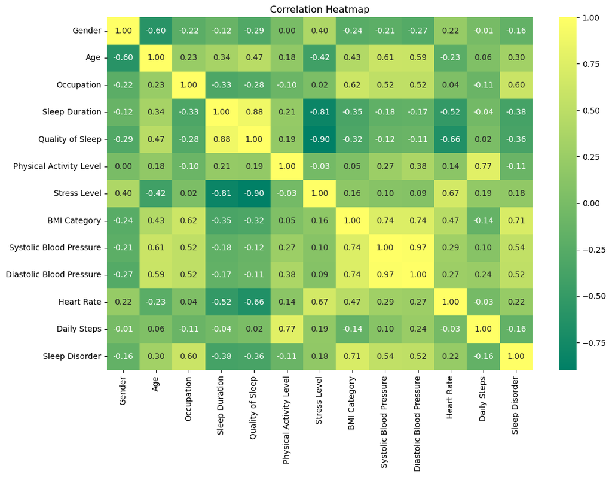

```python
### Draw a heatmap correlation to visualized the correlated
plt.figure(figsize=(12, 8))
corr = Sleep_Lifestyle_dt_2.corr()
sns.heatmap(corr, annot=True, cmap='summer', fmt='.2f')
plt.title('Correlation Heatmap')
plt.show()


#The below Heatmap shows that is correlated with occupation, the BMI Category and the blood pressure.
```

### Building and Evaluating the Models

** Before buidling the logistics Regression Model,

1. The class distribution is checked for to know if the data class distribution is balanced or imbalanced. If the class distribution is IMBALANCED, SMOTE will be applied after the train-test split, this is to avoid DATA LEAKAGE which can lead to Over-optimistic results and unrealistic performance evaluation.
2. It is also recommended that the SMOTE is applied to the Training sets alone which balances the class distribution for train data without affecting the Test sets. After which, it is scaled/normalized differently - Scale/Normalize the Train set and test set differently.
3. Evaluate and Build the Model.

This is approach that would be used in this project.... After considering the algorithm requirements, Logistics regression used in this project was standardized instead of normalized, this is because using StandardScaler to scale the features works better for logistics model works better than normalized data except if you want your data to be scaled between a particular/fixed range.

```python
## Copying/Saving the dataset into another dataframe
Sleep_Lifestyle_dt_3 = Sleep_Lifestyle_dt_2.copy()
Sleep_Lifestyle_dt_3.head()
```

|  | Gender | Age | Occupation | Sleep Duration | Quality of Sleep | Physical Activity Level | Stress Level | BMI Category | Systolic Blood Pressure | Diastolic Blood Pressure | Heart Rate | Daily Steps | Sleep Disorder |
| --- | --- | --- | --- | --- | --- | --- | --- | --- | --- | --- | --- | --- | --- |
| 0 | 1 | 27 | 10 | 6.1 | 6 | 42 | 6 | 2 | 126 | 83 | 77 | 4200 | 0 |
| 1 | 1 | 28 | 2 | 6.2 | 6 | 60 | 8 | 1 | 125 | 80 | 75 | 10000 | 0 |
| 2 | 1 | 28 | 2 | 6.2 | 6 | 60 | 8 | 1 | 125 | 80 | 75 | 10000 | 0 |
| 3 | 1 | 28 | 7 | 5.9 | 4 | 30 | 8 | 3 | 140 | 90 | 85 | 3000 | 1 |
| 4 | 1 | 28 | 7 | 5.9 | 4 | 30 | 8 | 3 | 140 | 90 | 85 | 3000 | 1 |

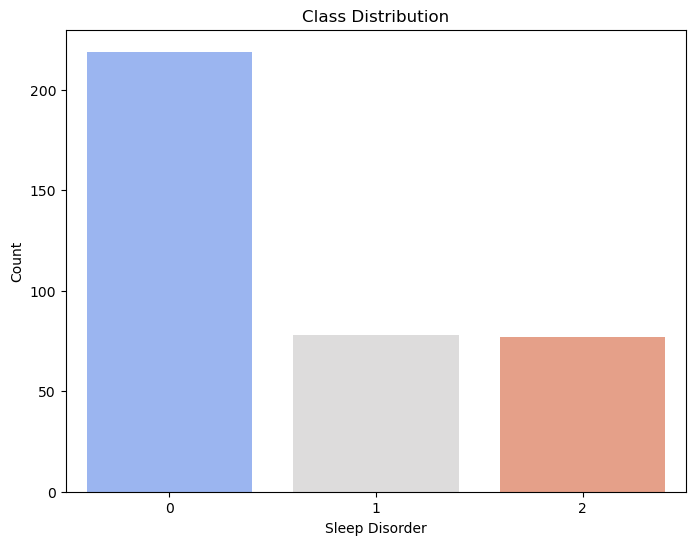

```python
#Checking for the class distribution in the dataset
plt.figure(figsize=(8, 6))
Sleep_Disorder_counts = Sleep_Lifestyle_dt_3['Sleep Disorder'].value_counts()
sns.barplot(x=Sleep_Disorder_counts.index, y=Sleep_Disorder_counts.values, palette='coolwarm')
plt.title('Class Distribution')
plt.xlabel('Sleep Disorder')
plt.ylabel('Count')
plt.show()
```

```python
# Splitting into input (features) and output (target)
X= Sleep_Lifestyle_dt_3.iloc[:, :-1]  # All rows, all columns except the last
y = Sleep_Lifestyle_dt_3.iloc[:, -1]   # All rows, only the last column

print(X.shape)
print(y.shape)
```

```
(374, 12)
(374,)
```

#### Splitting the Dataset into Training and Test sets

The stratify=y is used to ensure that the class distrubution in the training and test sets is similar to the class distribution in the original dataset. It ensures that the proportion of each class label is preserved in both training and test sets.This is particularly important for imbalanced datasets where some classes are underrepresented...

```python
#Split the data into train-test sample before smote on the Train data....and then standardize both the train and test data.

from sklearn.model_selection import train_test_split

# Split the data into training and test sets
X_train, X_test, y_train, y_test = train_test_split(X, y, test_size=0.3, random_state=123, stratify=y)
```

#### Applying SMOTE on the Training Set and Leaving the Test sets out to avoid Data Leakage

Data Leakage is the scenario where the Machine Learning Model is already aware of some part of test data after training.This causes the problem of overfitting. DATA LEAKAGE which can lead to Over-optimistic results and unrealistic performance evaluation. This is why the Test Set was left out in the Smote process

```python
from imblearn.over_sampling import SMOTE

# Applying SMOTE to the training data
sm = SMOTE(random_state=12345)
X_train_resampled, y_train_resampled = sm.fit_resample(X_train, y_train)
```

```python
from imblearn.over_sampling import SMOTE
from collections import Counter

# Original class distribution
print('Original dataset shape before applying smote to train dataset %s' % Counter(y))

# New class distribution
print('Resampled train dataset shape after applying smote %s' % Counter(y_train_resampled))
```

```
Original dataset shape before applying smote to train dataset Counter({0: 219, 1: 78, 2: 77})
Resampled train dataset shape after applying smote Counter({0: 153, 1: 153, 2: 153})
```

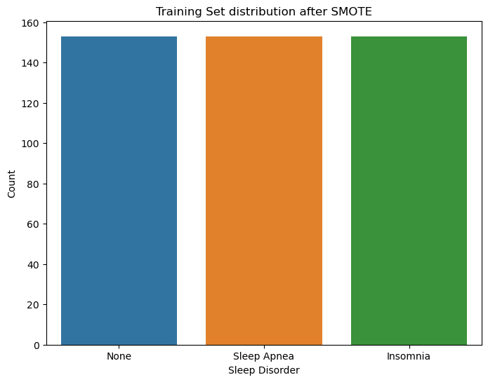

```python
# Plotting the class distribution after Smote has been applied to the dataset.
plt.figure(figsize=(8, 6))
sns.countplot(x=y_train_resampled)
plt.title('Training Set distribution after SMOTE')
plt.xlabel('Sleep Disorder')
plt.ylabel('Count')
plt.xticks([0, 1, 2], ['None', 'Sleep Apnea', 'Insomnia'])
plt.show()
```

#### Standardizing the Dataset (Train and Test sets) Before Building the model

```python
#Standardizing the dataset before using it in building my model
from sklearn.preprocessing import StandardScaler

# Initializing the scaler
scaler = StandardScaler()

# Fitting the scaler on the resampled training data and transforming it
X_train_resampled_scaled = scaler.fit_transform(X_train_resampled)

# Transform the test data using the same scaler
X_test_scaled = scaler.transform(X_test)
```

```python
# Displaying the train-test dataset shapes
print("Training data (resampled and scaled) shape:", X_train_resampled_scaled.shape)
print("Test data (scaled) shape:", X_test_scaled.shape)
```

```
Training data (resampled and scaled) shape: (459, 12)
Test data (scaled) shape: (113, 12)
```

##### Building the Logistics Regression Model with the Scaled Dataset

After considering the algorithm requirements, Logistics regression used in this project was standardized instead of normalized, this is because using StandardScaler to scale the features works better for logistics model works better than normalized data except if you want your data to be scaled between a particular/fixed range

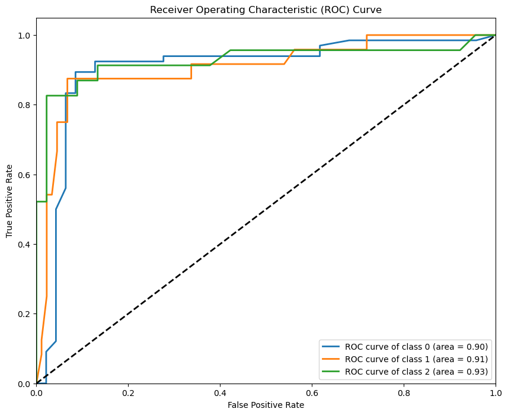

```
              precision    recall  f1-score   support

           0       0.94      0.88      0.91        66
           1       0.78      0.88      0.82        24
           2       0.79      0.83      0.81        23

    accuracy                           0.87       113
   macro avg       0.83      0.86      0.85       113
weighted avg       0.87      0.87      0.87       113

Overall AUC: 0.91
```

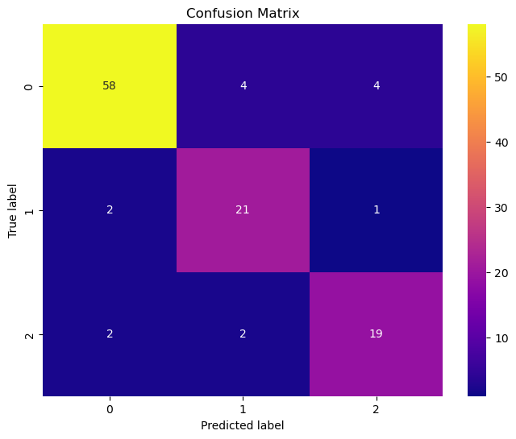

```python
from sklearn.linear_model import LogisticRegression
from sklearn.metrics import classification_report, roc_curve, roc_auc_score

# Logistic Regression model training using scaled train and test set
model = LogisticRegression()
model.fit(X_train_resampled_scaled, y_train_resampled)


# Predicting the probabilities on the test set to allow for computing the ROC-AUC curves
y_pred_proba = model.predict_proba(X_test_scaled)

# One-vs-Rest(ovr) ROC curves approach is used, which means treating each class as the positive class and the rest as negative.
fpr = {}
tpr = {}
roc_auc = {}

# Computing ROC curve and ROC area for each class
for i in range(3):
    fpr[i], tpr[i], _ = roc_curve(y_test, y_pred_proba[:, i], pos_label=i)
    roc_auc[i] = roc_auc_score(y_test == i, y_pred_proba[:, i])

# Plotting ROC curve for each class
plt.figure(figsize=(10, 8))
for i in range(3):
    plt.plot(fpr[i], tpr[i], lw=2, label=f'ROC curve of class {i} (area = {roc_auc[i]:0.2f})')

plt.plot([0, 1], [0, 1], 'k--', lw=2)
plt.xlim([0.0, 1.0])
plt.ylim([0.0, 1.05])
plt.xlabel('False Positive Rate')
plt.ylabel('True Positive Rate')
plt.title('Receiver Operating Characteristic (ROC) Curve')
plt.legend(loc="lower right")
plt.show()

# Predicting on the test set
y_pred = model.predict(X_test_scaled)

# Computimg the Classification Report on the Test data , Precision, Recall and F1-score for the multiclass
print(classification_report(y_test, y_pred))

# Calculate overall AUC
overall_auc = roc_auc_score(y_test, y_pred_proba, multi_class="ovr")
print(f'Overall AUC: {overall_auc:.2f}')


# Confusion Matrix for the logistics model built
conf_matrix = confusion_matrix(y_test, y_pred)

# Plotting Confusion Matrix
plt.figure(figsize=(8, 6))
sns.heatmap(conf_matrix, annot=True, cmap="plasma", fmt="d")
plt.xlabel('Predicted label')
plt.ylabel('True label')
plt.title('Confusion Matrix')
plt.show()
```

##### Building the Logistics Regression model with Lasso(L1 Regularization)

This is used to perform feature selection by shriking the less importance feature co-efficients to zero

```
Feature importance (Logistic Regression with L1):
Gender: 0.2071806996985279
Age: -0.8231407118385295
Occupation: 0.0
Sleep Duration: 0.0
Quality of Sleep: 2.5746341306056904
Physical Activity Level: 0.0
Stress Level: 0.7513201969945139
BMI Category: -0.3832616502577589
Systolic Blood Pressure: -0.17727254135424922
Diastolic Blood Pressure: 0.0
Heart Rate: 0.0
Daily Steps: 0.0
```

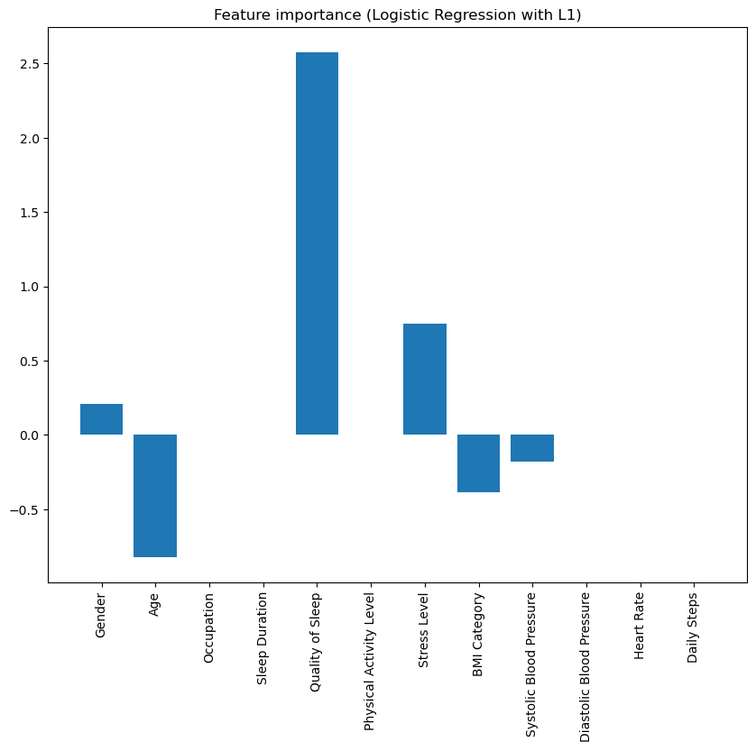

```python
from sklearn.linear_model import LogisticRegression

# Training a Logistic Regression model with L1 regularization
log_reg = LogisticRegression(penalty='l1', solver='saga', random_state=42)
log_reg.fit(X_train_resampled_scaled, y_train_resampled)

# Get the coefficients
coef = log_reg.coef_[0]

# Printing the feature importance
print("Feature importance (Logistic Regression with L1):")
for i, feature in enumerate(X.columns):
    print(f"{feature}: {coef[i]}")

# Plotting the  feature importance
plt.figure(figsize=(10, 8))
plt.bar(X.columns, coef)
plt.xticks(rotation=90)
plt.title("Feature importance (Logistic Regression with L1)")
plt.show()
```

##### Permutation Importance on Logistic Regression Model

**This can be used with any model to measure the effect of shuffling each feature on the model performance

** Permutation importance is a model-agnostic technique that helps determine the importance of features by measuring the increase in the model’s prediction error when the values of a single feature are randomly shuffled.

*** Positive Importance Scores: Feature is important for the model.

*** Near-Zero Scores: Feature is likely not contributing much to the model.

*** Negative Scores: Typically indicate noise or that the feature's shuffling accidentally improved the model due to noise in the dataset.

```
Permutation feature importance:
Quality of Sleep: 0.220 +/- 0.019
Diastolic Blood Pressure: 0.199 +/- 0.033
Sleep Duration: 0.126 +/- 0.026
Age: 0.097 +/- 0.019
Systolic Blood Pressure: 0.084 +/- 0.019
Daily Steps: 0.081 +/- 0.018
Gender: 0.061 +/- 0.012
Heart Rate: 0.057 +/- 0.015
Stress Level: 0.043 +/- 0.018
Physical Activity Level: 0.035 +/- 0.008
```

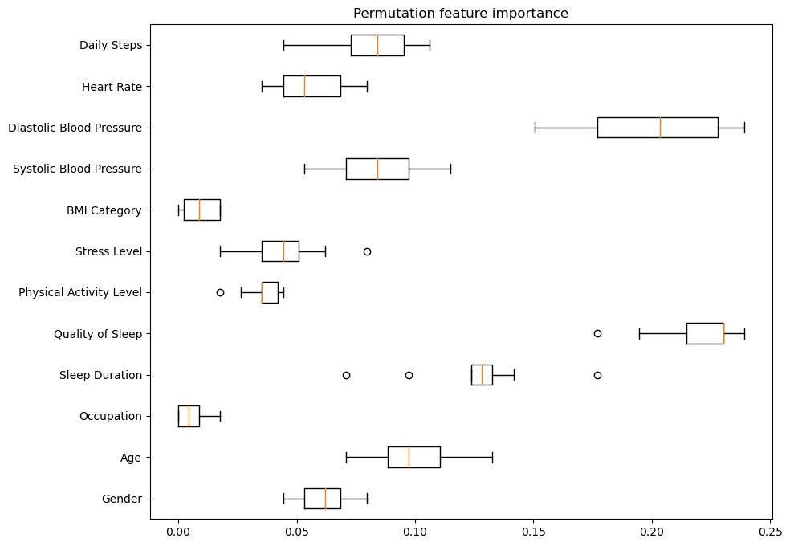

```python
from sklearn.inspection import permutation_importance

# Training the model (Using Logistics Regression Classifier)
model = LogisticRegression()
model.fit(X_train_resampled_scaled, y_train_resampled)


# Computing the permutation importance
result = permutation_importance(model, X_test_scaled, y_test, n_repeats=10, random_state=42)

# Printing the feature importance
print("Permutation feature importance:")
for i in result.importances_mean.argsort()[::-1]:
    if result.importances_mean[i] - 2 * result.importances_std[i] > 0:
        print(f"{X.columns[i]}: {result.importances_mean[i]:.3f} +/- {result.importances_std[i]:.3f}")

# Plotting the feature importance
plt.figure(figsize=(10, 8))
plt.boxplot(result.importances.T, vert=False, labels=X.columns)
plt.title("Permutation feature importance")
plt.show()
```

##### Building a RandomForest Classifier

** Random Forest:is a Tree-based method which is generally robust to feature scaling, but sometimes it can benefit from scaling if there are significant disparities in feature ranges. So therefore, the scaled features would not be used but the actual smote training set and actual test set. However, for comparism the scaled and unscaled dataset would be used to check/prove the effect of feature scaling/normalizing on Tree based Models

Let's dive in

##### Building the RF Classifier using the scaled Train and Test data features

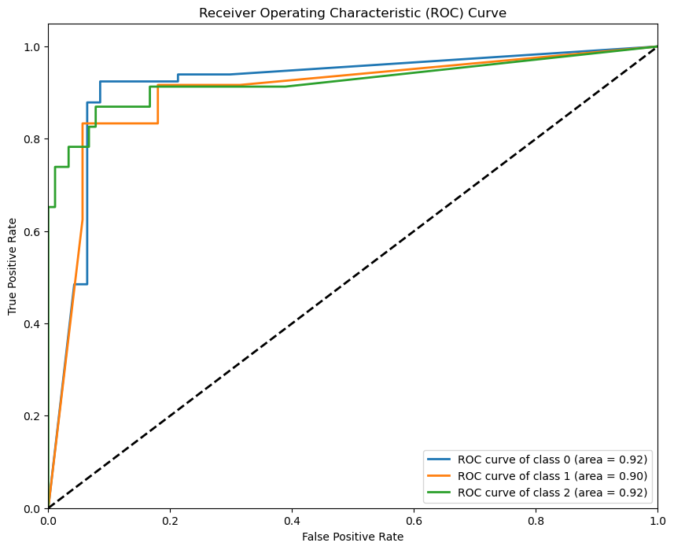

```
              precision    recall  f1-score   support

           0       0.95      0.83      0.89        66
           1       0.69      0.83      0.75        24
           2       0.73      0.83      0.78        23

    accuracy                           0.83       113
   macro avg       0.79      0.83      0.81       113
weighted avg       0.85      0.83      0.84       113

Overall AUC: 0.91
```

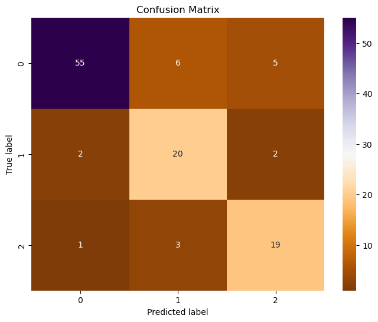

```python
# Train the model using the scaled training set and test set...
### The results shows the same as with the unscaled training set and test set

from sklearn.ensemble import RandomForestClassifier
from sklearn.metrics import classification_report, roc_curve, roc_auc_score

model = RandomForestClassifier(random_state=42)
model.fit(X_train_resampled_scaled, y_train_resampled)

# Predicting the probabilities on the test set
y_pred_proba = model.predict_proba(X_test_scaled)

# One-vs-Rest(ovr) ROC curves approach is used, which means treating each class as the positive class and the rest as negative.
fpr = {}
tpr = {}
roc_auc = {}

# Computing ROC curve and ROC area for each class
for i in range(3):
    fpr[i], tpr[i], _ = roc_curve(y_test, y_pred_proba[:, i], pos_label=i)
    roc_auc[i] = roc_auc_score(y_test == i, y_pred_proba[:, i])

# Plotting ROC curve for each class
plt.figure(figsize=(10, 8))
for i in range(3):
    plt.plot(fpr[i], tpr[i], lw=2, label=f'ROC curve of class {i} (area = {roc_auc[i]:0.2f})')

plt.plot([0, 1], [0, 1], 'k--', lw=2)
plt.xlim([0.0, 1.0])
plt.ylim([0.0, 1.05])
plt.xlabel('False Positive Rate')
plt.ylabel('True Positive Rate')
plt.title('Receiver Operating Characteristic (ROC) Curve')
plt.legend(loc="lower right")
plt.show()

# Printing the classification report
y_pred = model.predict(X_test_scaled)
print(classification_report(y_test, y_pred))

# Calculating the overall AUC
overall_auc = roc_auc_score(y_test, y_pred_proba, multi_class="ovr")
print(f'Overall AUC: {overall_auc:.2f}')


# Confusion Matrix for the Random Forest Classifier built
conf_matrix = confusion_matrix(y_test, y_pred)

# Plotting Confusion Matrix
plt.figure(figsize=(8, 6))
sns.heatmap(conf_matrix, annot=True, cmap="PuOr", fmt="d")
plt.xlabel('Predicted label')
plt.ylabel('True label')
plt.title('Confusion Matrix')
plt.show()
```

##### Building the RF Classifier using the unscaled Train and Test data features

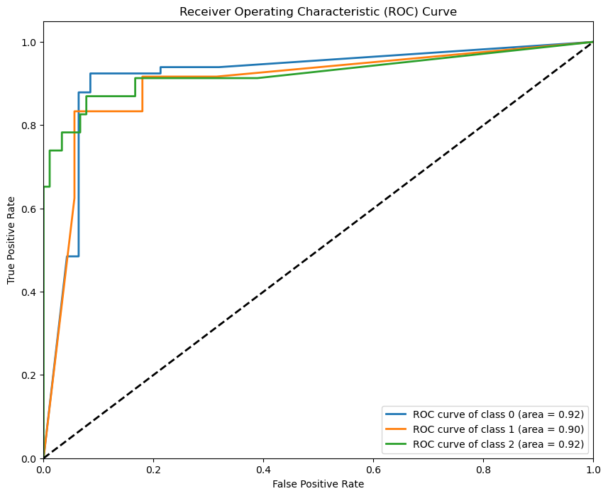

```
              precision    recall  f1-score   support

           0       0.95      0.83      0.89        66
           1       0.69      0.83      0.75        24
           2       0.73      0.83      0.78        23

    accuracy                           0.83       113
   macro avg       0.79      0.83      0.81       113
weighted avg       0.85      0.83      0.84       113

Overall AUC: 0.91
```

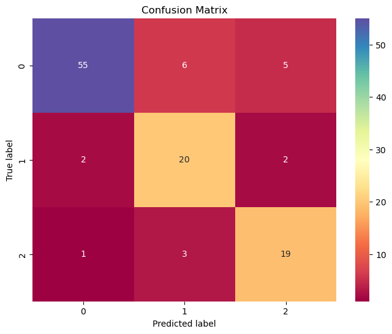

```python
#Building the Random Forest with an Unscaled dataset because RandomForest Classifier is robust to feature scaling..
from sklearn.ensemble import RandomForestClassifier
from sklearn.metrics import classification_report

# Training a Rf model
model = RandomForestClassifier(random_state=42)
model.fit(X_train_resampled, y_train_resampled)


# Predicting the probabilities on the test set for ROC-AUC Curves
y_pred_proba = model.predict_proba(X_test)

# One-vs-Rest(ovr) ROC curves approach is used, which means treating each class as the positive class and the rest as negative.
fpr = {}
tpr = {}
roc_auc = {}

# Computing ROC curve and ROC area for each class
for i in range(3):
    fpr[i], tpr[i], _ = roc_curve(y_test, y_pred_proba[:, i], pos_label=i)
    roc_auc[i] = roc_auc_score(y_test == i, y_pred_proba[:, i])

# Plotting ROC curve for each class
plt.figure(figsize=(10, 8))
for i in range(3):
    plt.plot(fpr[i], tpr[i], lw=2, label=f'ROC curve of class {i} (area = {roc_auc[i]:0.2f})')

plt.plot([0, 1], [0, 1], 'k--', lw=2)
plt.xlim([0.0, 1.0])
plt.ylim([0.0, 1.05])
plt.xlabel('False Positive Rate')
plt.ylabel('True Positive Rate')
plt.title('Receiver Operating Characteristic (ROC) Curve')
plt.legend(loc="lower right")
plt.show()


# Predicting on the test set
y_pred = model.predict(X_test)

# Printing the classification report - Precision, Accuracy, Recall and F1=Score
print(classification_report(y_test, y_pred))

# Calculating the overall AUC
overall_auc = roc_auc_score(y_test, y_pred_proba, multi_class="ovr")
print(f'Overall AUC: {overall_auc:.2f}')


# Confusion Matrix for the Random Forest model built
conf_matrix = confusion_matrix(y_test, y_pred)
# Plotting Confusion Matrix
plt.figure(figsize=(8, 6))
sns.heatmap(conf_matrix, annot=True, cmap="Spectral", fmt="d")
plt.xlabel('Predicted label')
plt.ylabel('True label')
plt.title('Confusion Matrix')
plt.show()
```

###### Performing a Feature Importance on the RF Model (Unscaled Train and Test set)

```
Feature ranking:
1. feature 8 (0.19117753537799462)
2. feature 7 (0.15298110534542728)
3. feature 9 (0.14871868765675605)
4. feature 2 (0.09493627240222118)
5. feature 5 (0.08850916658586262)
6. feature 1 (0.07889117694707613)
7. feature 3 (0.07778679524420662)
8. feature 11 (0.07273214788535942)
9. feature 10 (0.03538471973947354)
10. feature 4 (0.025333079525485646)
11. feature 0 (0.01736080512535727)
12. feature 6 (0.016188508164779673)
```

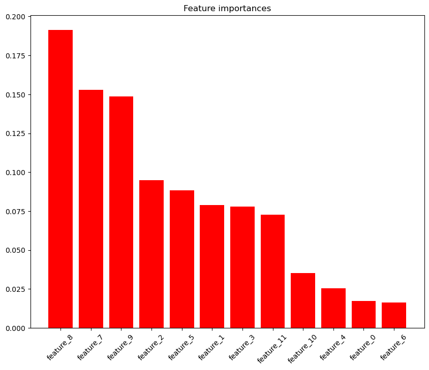

```python
# Tree based models provide features importance scores directly which can be used to identify the most of important features
# Get feature importances that contributes to the prediction of the model (Unscaled Dataset)
importances = model.feature_importances_
indices = np.argsort(importances)[::-1]

# Printing the feature ranking
print("Feature ranking:")

for f in range(X_train_resampled.shape[1]):
    print(f"{f + 1}. feature {indices[f]} ({importances[indices[f]]})")

# Plotting the feature importances of the forest
plt.figure(figsize=(10, 8))
plt.title("Feature importances")
plt.bar(range(X_train_resampled.shape[1]), importances[indices],
       color="r", align="center")
plt.xticks(range(X_train_resampled.shape[1]), [f'feature_{i}' for i in indices], rotation=45)
plt.xlim([-1, X_train_resampled.shape[1]])
plt.show()



#Note: Feature 0= Gender, Feature 1= Age, Feature 2= Occupation, Feature 3= Sleep Duration, Feature 4= Quality of Sleep,
# Feature 5 = Physical Activity Level, Feature 6= Stress Level, Feature 7= BMI category, Feature 8= Systolic Blood Pressure
# Feature 9= Diastolic Blood Pressure, Feature 10= Heart Rate, Feature 11= Daily Steps
```

##### Using Permutation Importance for feature Importance for comparism on the RF Classifier

```
Permutation feature importance:
```

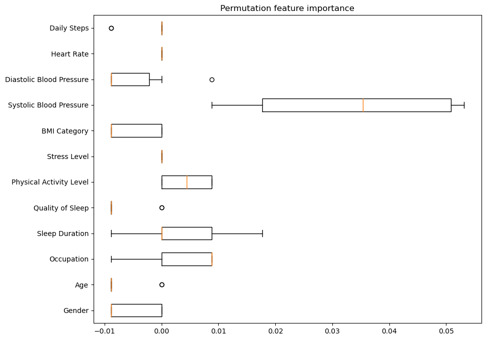

```python
#### Using Permutation Importance
from sklearn.inspection import permutation_importance

# Training the model (Using RandomForest Classifier)
model = RandomForestClassifier(random_state=42)
model.fit(X_train_resampled, y_train_resampled)

# Computing the permutation importance
result = permutation_importance(model, X_test, y_test, n_repeats=10, random_state=42)

# Printing feature importance
print("Permutation feature importance:")
for i in result.importances_mean.argsort()[::-1]:
    if result.importances_mean[i] - 2 * result.importances_std[i] > 0:
        print(f"{X.columns[i]}: {result.importances_mean[i]:.3f} +/- {result.importances_std[i]:.3f}")

# Plotting the feature importance
plt.figure(figsize=(10, 8))
plt.boxplot(result.importances.T, vert=False, labels=X.columns)
plt.title("Permutation feature importance")
plt.show()
```

### Feature Importance Intrepretation from RF Classifier Feature Importance score and Permutation Importance Feature Score for logistics model and RandomForest Classifier

From Research online from Sleep and Hypertension National Issue of Healths (NIH) article, it shows that Both sleep deprivation and insomnia have been linked to increases in incidence and prevalence of hypertension. (https://www.ncbi.nlm.nih.gov/pmc/articles/PMC2913764/)

It's also possible that HBP may make sleep more difficult. HBP occurs when the force of blood pumping through your veins is high. This puts stress on your blood vessels and can cause symptoms such as headaches, chest pain, and difficulty breathing. All these symptoms can make sleep difficult. Meanwhile, Sleep apnea is defined as a breathing disorder that affects sleep. (https://www.healthline.com/health/high-blood-pressure/can-high-blood-pressure-cause-insomnia)

In this Project, a multiclass a logistics regression (LR) model and Random Forest (RF) Model was built. LR has an accuracy of 87% and RF has an accuracy of 83% on the test data while both has an overall AUC of 91% indicates that the models has a high ability to distinguish between classes.